# Homework 4: Naive Bayes

```r
library(caret)
library(e1071)
library(ROCR)
library(nutshell)
Train<-read.csv("accidents_train.csv")
View(Train)
str(Train)
```

```
## 'data.frame':    31638 obs. of  24 variables:
##  $ HOUR_I_R      : Factor w/ 2 levels "Not rush hour",..: 1 2 2 2 2 2 2 2 2 2 ...
##  $ ALCHL_I       : Factor w/ 2 levels "Alcohol involved",..: 2 2 2 2 2 2 2 2 2 2 ...
##  $ ALIGN_I       : Factor w/ 2 levels "Curve","Straight": 1 2 2 2 2 2 2 2 2 1 ...
##  $ STRATUM_R     : Factor w/ 2 levels "NASS Crashes Involving At Least One Passenger Vehicle",..: 1 1 1 2 1 1 2 1 1 2 ...
##  $ WRK_ZONE      : Factor w/ 2 levels "No","Yes": 1 1 1 1 1 1 1 1 1 1 ...
##  $ WKDY_I_R      : Factor w/ 2 levels "Weekday","Weekend": 1 2 1 1 1 1 1 1 1 1 ...
##  $ INT_HWY       : Factor w/ 2 levels "No","Yes": 1 1 1 2 1 1 1 1 1 1 ...
##  $ LGTCON_I_R    : Factor w/ 3 levels "Dark","Dark, but lighted",..: 2 2 2 2 2 2 2 2 2 2 ...
##  $ MANCOL_I_R    : Factor w/ 3 levels "Head-on","No collision",..: 2 3 2 2 2 2 2 3 1 2 ...
##  $ PED_ACC_R     : Factor w/ 2 levels "Not involved",..: 1 1 1 1 1 1 1 1 1 1 ...
##  $ RELJCT_I_R    : Factor w/ 2 levels "Accident at intersection.interchange",..: 1 1 1 2 2 1 2 2 2 2 ...
##  $ REL_RWY_R     : Factor w/ 2 levels "Accident on roadway",..: 2 1 2 2 2 2 2 1 1 2 ...
##  $ PROFIL_I_R    : Factor w/ 2 levels "Level","Other": 1 1 1 1 1 1 1 1 1 1 ...
##  $ SPD_LIM       : int  40 35 70 70 35 30 55 40 40 25 ...
##  $ SUR_COND      : Factor w/ 5 levels "Dry","Ice","Snow/Slush",..: 2 2 2 2 2 2 2 2 2 2 ...
##  $ TRAF_CON_R    : Factor w/ 3 levels "None","Other",..: 1 3 1 1 1 1 1 2 1 1 ...
##  $ TRAF_WAY      : Factor w/ 3 levels "Divieded highway",..: 2 1 1 1 3 3 3 3 3 3 ...
##  $ VEH_INVL      : int  1 2 1 1 1 1 1 2 4 1 ...
##  $ WEATHER_R     : Factor w/ 2 levels "No adverse conditions",..: 1 1 2 2 1 2 2 1 1 1 ...
##  $ INJURY_CRASH  : Factor w/ 2 levels "No","Yes": 2 1 2 1 2 1 1 1 2 1 ...
##  $ NO_INJ_I      : int  1 0 1 0 1 0 0 0 2 0 ...
##  $ PRPTYDMG_CRASH: Factor w/ 2 levels "No property damage",..: 1 2 1 2 1 2 2 2 1 2 ...
##  $ FATALITIES    : Factor w/ 2 levels "No","Yes": 1 1 1 1 1 1 1 1 1 1 ...
##  $ INJURY        : Factor w/ 2 levels "No","Yes": 2 1 2 1 2 1 1 1 2 1 ...
```

# Question 1

```r
prop.table(table(Train$INJURY))*100
```

```
##
##       No      Yes
## 49.12131 50.87869
```

The probability of predicting injury is 50.87% and not injury 49.12% which means that after each new accident it is more probable to predict people being injured rather than not injured.

# Question 2

```r
prop.table(table(Train$INJURY,Train$ALIGN_I),1)
```

```
##
##           Curve  Straight
##   No  0.1283058 0.8716942
##   Yes 0.1346835 0.8653165
```

```r
prop.table(table(Train$INJURY,Train$WKDY_I_R),1)
```

```
##
##         Weekday   Weekend
##   No  0.7818030 0.2181970
##   Yes 0.7605765 0.2394235
```

P(Weekday|Yes)=0.76  
P(Weekday|No)=0.78

```r
prop.table(table(Train$INJURY, Train$SUR_COND),1)
```

```
##
##               Dry         Ice  Snow/Slush     Unknown         Wet
##   No  0.777298758 0.027347018 0.016987324 0.003989447 0.174377453
##   Yes 0.815555694 0.015344474 0.010312481 0.004597130 0.154190222
```

P(Snow/Slush|Yes)=0.01  
P(Snow/Slush|No)=0.016 P(Yes)=0.509 P(No)=0.491

```r
(0.509*0.87*0.76*0.01)/(0.509*0.87*0.76*0.01+0.491*0.87*0.78*0.016)
```

```
## [1] 0.3869917
```

The probability of being injured is 38.7% given that road alignment is straight, it is weekday and road surface is snow/slash.

# Question 3-5

```r
paste(names(Train), collapse ="+")
```

```
## [1] "HOUR_I_R+ALCHL_I+ALIGN_I+STRATUM_R+WRK_ZONE+WKDY_I_R+INT_HWY+LGTCON_I_R+MANCOL_I_R+PED_ACC_R+RELJCT_I_R+REL_RWY_R+PROFIL_I_R+SPD_LIM+SUR_COND+TRAF_CON_R+TRAF_WAY+VEH_INVL+WEATHER_R+INJURY_CRASH+NO_INJ_I+PRPTYDMG_CRASH+FATALITIES+INJURY"
```

I have keep only 11 explanatory variables in the final model as other variables like “fatalities”,“injury crash”, “alcohol ivolve or not” etc can be known only after the report about accident. So the final formula is the folowing.

```r
frm<-"INJURY ~HOUR_I_R+ WRK_ZONE+ALIGN_I+WKDY_I_R+INT_HWY+LGTCON_I_R+REL_RWY_R+SUR_COND+TRAF_WAY+WEATHER_R+RELJCT_I_R"
```

To understand the relationship between included variables and “injury”" I have run Chi-Square test.

```r
chisq.test(Train$INJURY,Train$HOUR_I_R,simulate.p.value=T)
```

```
##
##  Pearson's Chi-squared test with simulated p-value (based on 2000
##  replicates)
##
## data:  Train$INJURY and Train$HOUR_I_R
## X-squared = 0.7396, df = NA, p-value = 0.4008
```

```r
chisq.test(Train$INJURY,Train$WKDY_I_R,simulate.p.value=T)
```

```
##
##  Pearson's Chi-squared test with simulated p-value (based on 2000
##  replicates)
##
## data:  Train$INJURY and Train$WKDY_I_R
## X-squared = 20.178, df = NA, p-value = 0.0004998
```

```r
chisq.test(Train$INJURY,Train$INT_HWY,simulate.p.value=T)
```

```
##
##  Pearson's Chi-squared test with simulated p-value (based on 2000
##  replicates)
##
## data:  Train$INJURY and Train$INT_HWY
## X-squared = 6.5211, df = NA, p-value = 0.01399
```

```r
chisq.test(Train$INJURY,Train$LGTCON_I_R,simulate.p.value=T)
```

```
##
##  Pearson's Chi-squared test with simulated p-value (based on 2000
##  replicates)
##
## data:  Train$INJURY and Train$LGTCON_I_R
## X-squared = 11.216, df = NA, p-value = 0.004998
```

```r
chisq.test(Train$INJURY,Train$WEATHER_R,simulate.p.value=T)
```

```
##
##  Pearson's Chi-squared test with simulated p-value (based on 2000
##  replicates)
##
## data:  Train$INJURY and Train$WEATHER_R
## X-squared = 59.576, df = NA, p-value = 0.0004998
```

```r
chisq.test(Train$INJURY,Train$REL_RWY_R,simulate.p.value=T)
```

```
##
##  Pearson's Chi-squared test with simulated p-value (based on 2000
##  replicates)
##
## data:  Train$INJURY and Train$REL_RWY_R
## X-squared = 27.411, df = NA, p-value = 0.0004998
```

```r
chisq.test(Train$INJURY,Train$SUR_COND,simulate.p.value=T)
```

```
##
##  Pearson's Chi-squared test with simulated p-value (based on 2000
##  replicates)
##
## data:  Train$INJURY and Train$SUR_COND
## X-squared = 114.39, df = NA, p-value = 0.0004998
```

```r
chisq.test(Train$INJURY,Train$TRAF_WAY, simulate.p.value=T)
```

```
##
##  Pearson's Chi-squared test with simulated p-value (based on 2000
##  replicates)
##
## data:  Train$INJURY and Train$TRAF_WAY
## X-squared = 29.205, df = NA, p-value = 0.0004998
```

```r
library(e1071)
Bmodel<-naiveBayes(INJURY~HOUR_I_R+WRK_ZONE+ALIGN_I+WKDY_I_R+INT_HWY+LGTCON_I_R+REL_RWY_R+SUR_COND+TRAF_WAY+WEATHER_R+RELJCT_I_R, data=Train, laplace=1)
```

```r
Bmodel$apriori
```

```
## Y
##    No   Yes
## 15541 16097
```

```r
Bmodel$tables
```

```
## $HOUR_I_R
##      HOUR_I_R
## Y     Not rush hour Rush hour
##   No      0.5682301 0.4317699
##   Yes     0.5730170 0.4269830
##
## $WRK_ZONE
##      WRK_ZONE
## Y             No        Yes
##   No  0.97619507 0.02380493
##   Yes 0.97894279 0.02105721
##
## $ALIGN_I
##      ALIGN_I
## Y         Curve  Straight
##   No  0.1283536 0.8716464
##   Yes 0.1347289 0.8652711
##
## $WKDY_I_R
##      WKDY_I_R
## Y       Weekday   Weekend
##   No  0.7817667 0.2182333
##   Yes 0.7605441 0.2394559
##
## $INT_HWY
##      INT_HWY
## Y            No       Yes
##   No  0.8502639 0.1497361
##   Yes 0.8603654 0.1396346
##
## $LGTCON_I_R
##      LGTCON_I_R
## Y          Dark Dark, but lighted       Day
##   No  0.1235203         0.1843155 0.6921642
##   Yes 0.1122981         0.1922360 0.6954658
##
## $REL_RWY_R
##      REL_RWY_R
## Y     Accident on roadway Not on roadway
##   No            0.7564177      0.2435823
```

[output cut: 10 more lines]

```
## Y     Divieded highway One-way road Two-way traffic
##   No        0.37287699   0.05120947      0.57591354
##   Yes       0.39664596   0.04192547      0.56142857
##
## $WEATHER_R
##      WEATHER_R
## Y     No adverse conditions Rain, snow or other adverse conditions
##   No              0.8415364                              0.1584636
##   Yes             0.8719175                              0.1280825
##
## $RELJCT_I_R
##      RELJCT_I_R
## Y     Accident at intersection.interchange Not at intersection
##   No                             0.5411439           0.4588561
##   Yes                            0.5765576           0.4234424
```

# Testing, Confusion Matrix

```r
library(caret)
Test<-read.csv("accidents_test.csv")
Predict <- predict(Bmodel, newdata = Test )
confusionMatrix(Predict, Test$INJURY, positive = "Yes")
```

```
## Confusion Matrix and Statistics
##
##           Reference
## Prediction   No  Yes
##        No  1860 1623
##        Yes 3320 3742
##
##                Accuracy : 0.5312
##                  95% CI : (0.5217, 0.5408)
##     No Information Rate : 0.5088
##     P-Value [Acc > NIR] : 2.026e-06
##
##                   Kappa : 0.0569
##  Mcnemar's Test P-Value : < 2.2e-16
##
##             Sensitivity : 0.6975
##             Specificity : 0.3591
##          Pos Pred Value : 0.5299
##          Neg Pred Value : 0.5340
##              Prevalence : 0.5088
##          Detection Rate : 0.3549
##    Detection Prevalence : 0.6697
##       Balanced Accuracy : 0.5283
##
##        'Positive' Class : Yes
##
```

# Roc Curve and AUC for Naive Bayes model

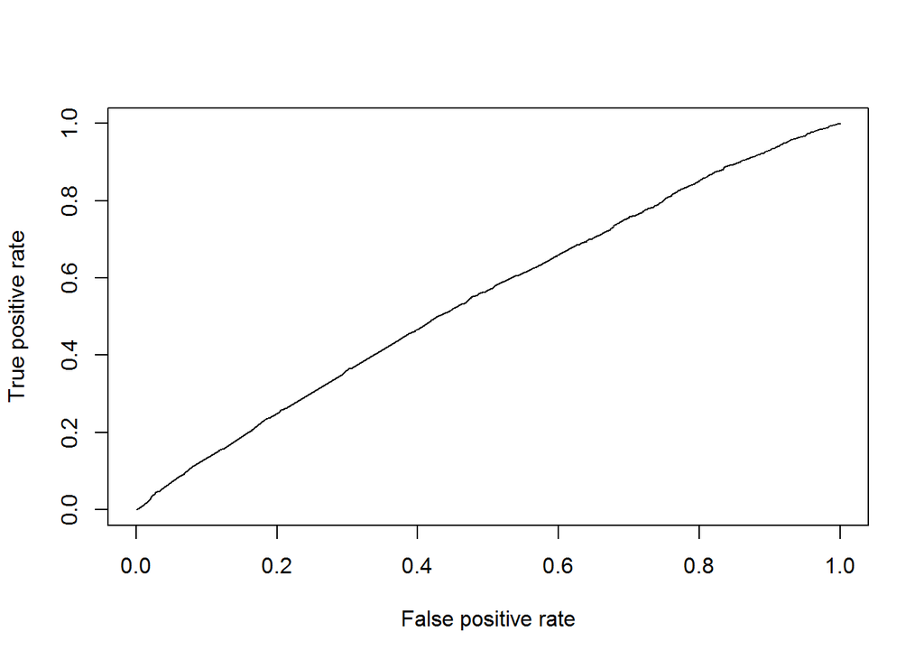

```r
bayes<-predict(Bmodel,newdata=Test, type="raw")
library(ROCR)
P_Test <- prediction(bayes[,2],Test$INJURY)
perf1<- performance(P_Test,"tpr","fpr")
plot(perf1)
```

```r
AUC_1<-performance(P_Test, "auc")@y.values
AUC_1
```

```
## [[1]]
## [1] 0.5487119
```

From the confusion matrix and ROC curve it can be seen that overall accuracy of the model is not high. AUC=54.87% and Accuracy=53.12%.Sensitivity of the model represents that model was 69.75% accurate predicting people who got injuries given that they were actually injured. Specificity shows that 35.91% of all not injured people were predicted to be not injured. This means the model more accurately classifies injured people rather than not injured.

# Question 6

This model can be used by health care organizations and the government. Health care organizations can use this information to understand which locations and conditions are more probable to cause more injuries, so they can choose where to build hospitals, they will be more prepared and will have more staff those days when car accidents and injuries are more likely to happen. Second, the government can use this analysis in order to try to decrease the rate of injuries by improving road conditions and other factors which can bring to car accidents and more injuries.

# Logistic Regression

```r
logit<-glm(INJURY ~HOUR_I_R+WRK_ZONE+ALIGN_I+WKDY_I_R+INT_HWY+LGTCON_I_R+REL_RWY_R+SUR_COND+TRAF_WAY+WEATHER_R+RELJCT_I_R,data=Train, family ="binomial")
summary(logit)
```

```
##
## Call:
## glm(formula = INJURY ~ HOUR_I_R + WRK_ZONE + ALIGN_I + WKDY_I_R +
##     INT_HWY + LGTCON_I_R + REL_RWY_R + SUR_COND + TRAF_WAY +
##     WEATHER_R + RELJCT_I_R, family = "binomial", data = Train)
##
## Deviance Residuals:
##    Min      1Q  Median      3Q     Max
## -1.436  -1.204   1.018   1.151   1.569
##
## Coefficients:
##                                                 Estimate Std. Error
## (Intercept)                                      0.38584    0.05686
## HOUR_I_RRush hour                               -0.01540    0.02322
## WRK_ZONEYes                                     -0.11478    0.07719
## ALIGN_IStraight                                 -0.18240    0.03571
## WKDY_I_RWeekend                                  0.12855    0.02740
## INT_HWYYes                                      -0.07892    0.03806
## LGTCON_I_RDark, but lighted                      0.07569    0.04316
## LGTCON_I_RDay                                    0.02459    0.03770
## REL_RWY_RNot on roadway                         -0.08061    0.03066
## SUR_CONDIce                                     -0.52072    0.08728
## SUR_CONDSnow/Slush                              -0.42415    0.10952
## SUR_CONDUnknown                                  0.09535    0.17304
## SUR_CONDWet                                     -0.09799    0.04915
## TRAF_WAYOne-way road                            -0.38511    0.05779
## TRAF_WAYTwo-way traffic                         -0.15116    0.02706
## WEATHER_RRain, snow or other adverse conditions -0.10292    0.05415
## RELJCT_I_RNot at intersection                   -0.14263    0.02660
##                                                 z value Pr(>|z|)
## (Intercept)                                       6.786 1.16e-11 ***
## HOUR_I_RRush hour                                -0.663 0.507199
## WRK_ZONEYes                                      -1.487 0.137024
## ALIGN_IStraight                                  -5.108 3.26e-07 ***
## WKDY_I_RWeekend                                   4.691 2.72e-06 ***
## INT_HWYYes                                       -2.073 0.038148 *
## LGTCON_I_RDark, but lighted                       1.754 0.079443 .
## LGTCON_I_RDay                                     0.652 0.514289
## REL_RWY_RNot on roadway                          -2.629 0.008567 **
## SUR_CONDIce                                      -5.966 2.43e-09 ***
## SUR_CONDSnow/Slush                               -3.873 0.000108 ***
## SUR_CONDUnknown                                   0.551 0.581621
## SUR_CONDWet                                      -1.994 0.046171 *
## TRAF_WAYOne-way road                             -6.664 2.67e-11 ***
## TRAF_WAYTwo-way traffic                          -5.586 2.32e-08 ***
## WEATHER_RRain, snow or other adverse conditions  -1.901 0.057349 .
## RELJCT_I_RNot at intersection                    -5.362 8.22e-08 ***
## ---
## Signif. codes:  0 '***' 0.001 '**' 0.01 '*' 0.05 '.' 0.1 ' ' 1
##
## (Dispersion parameter for binomial family taken to be 1)
##
##     Null deviance: 43828  on 31621  degrees of freedom
## Residual deviance: 43570  on 31605  degrees of freedom
##   (16 observations deleted due to missingness)
## AIC: 43604
##
## Number of Fisher Scoring iterations: 4
```

```r
PredTest_log<-predict(logit,newdata = Test, type="response")
table(PredTest_log>0.5, Test$INJURY)
```

```
##
##           No  Yes
##   FALSE 2036 1724
##   TRUE  3142 3631
```

```r
pr_label <-ifelse(PredTest_log>0.5, "Yes", "No")
con<-confusionMatrix(pr_label,Test$INJURY, positive="Yes")
con
```

```
## Confusion Matrix and Statistics
##
##           Reference
## Prediction   No  Yes
##        No  2036 1724
##        Yes 3142 3631
##
##                Accuracy : 0.538
##                  95% CI : (0.5284, 0.5476)
##     No Information Rate : 0.5084
##     P-Value [Acc > NIR] : 6.204e-10
##
##                   Kappa : 0.0716
##  Mcnemar's Test P-Value : < 2.2e-16
##
##             Sensitivity : 0.6781
##             Specificity : 0.3932
##          Pos Pred Value : 0.5361
##          Neg Pred Value : 0.5415
##              Prevalence : 0.5084
##          Detection Rate : 0.3447
##    Detection Prevalence : 0.6430
##       Balanced Accuracy : 0.5356
##
##        'Positive' Class : Yes
##
```

# ROC Curve and AUC

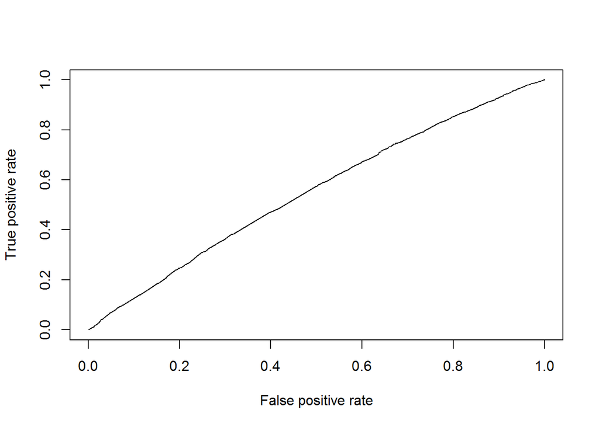

```r
P_Test2 <- prediction(PredTest_log, Test$INJURY)
perf2 <- performance(P_Test2,"tpr","fpr")
plot(perf2)
```

```r
performance(P_Test2, "auc")@y.values
```

```
## [[1]]
## [1] 0.5507984
```